# Ejemplo 1 (indicadores continuos): uso de IA en escuelas de economía, datos agregados

```r
library(lavaan)
library(semTools)
knitr::opts_chunk$set(message = FALSE, warning = FALSE)
```

# 1. El constructo y los indicadores

**Unidad de análisis:** la escuela (o facultad) de economía, no el estudiante.

**Constructo:** *intensidad del uso de IA en la escuela*, es decir, qué tan extendido y qué tan severo es el uso de IA entre sus estudiantes, desde usos leves y ocasionales hasta usos habituales que reemplazan el trabajo propio.

**Cuestionario a estudiantes:** *“Durante este semestre, ¿con qué frecuencia…?”* Respuesta: Nunca / Una vez / A veces / Siempre o casi siempre.

**Indicadores de la escuela:** porcentaje de estudiantes que alcanza cierto nivel de frecuencia en una conducta. Así, una misma conducta genera indicadores más o menos severos:

- “al menos una vez”: uso leve, porcentaje alto;
- “a veces o más”: uso regular;
- “siempre o casi siempre”: uso habitual, más severo, porcentaje bajo.

**Escala A**

| Ind. | % de estudiantes que… | Frecuencia |
| --- | --- | --- |
| a1 | …pidió a una IA que le explicara un concepto | al menos una vez |
| a2 | …pidió a una IA que le explicara un concepto | siempre |
| a3 | …usó IA para comprobar sus respuestas a ejercicios | a veces o más |
| a4 | …usó IA para resolver un ejercicio completo | al menos una vez |
| a5 | …usó IA para resolver un ejercicio completo | siempre |
| a6 | …entregó código generado por IA sin entenderlo | a veces o más |
| a7 | …entregó párrafos escritos por IA sin modificarlos | al menos una vez |
| a8 | …entregó párrafos escritos por IA sin modificarlos | a veces o más |

**Escala B**

| Ind. | % de estudiantes que… | Frecuencia | Comentario |
| --- | --- | --- | --- |
| b1 | …pidió a una IA que le explicara un concepto | al menos una vez |  |
| b2 | …usó IA para comprobar sus respuestas | al menos una vez |  |
| b3 | …usó IA para comprobar sus respuestas | siempre |  |
| b4 | …usó IA para resolver un ejercicio completo | a veces o más |  |
| b5 | …entregó código de IA sin entenderlo | al menos una vez |  |
| b6 | …entregó código de IA sin entenderlo | siempre |  |
| b7 | …usó IA en una evaluación donde estaba prohibido | al menos una vez |  |
| b8 | …ha usado IA para cualquier cosa | al menos una vez | **Techo:** ~95%, no distingue escuelas |
| b9 | …usa IA para temas personales (no académicos) | siempre | **Otro constructo:** uso general / afinidad tecnológica |
| b10 | …usa IA para entretenimiento o redes sociales | siempre | **Otro constructo**; covaría con b9 |

# 2. Los datos

Usamos datos de 400 escuelas de economía (archivo `escuelas_ia.csv`, que debe estar en la misma carpeta que este documento).

| Variable | Descripción |
| --- | --- |
| `escuela` | Identificador de la escuela |
| `n_est` | Número de estudiantes encuestados en la escuela (30 a 200) |
| `cuant` | Orientación cuantitativa del currículo (estandarizada) |
| `recursos` | Recursos tecnológicos de la escuela (estandarizada) |
| `eta` | Intensidad **verdadera** de uso de IA (estandarizada) |
| `a1`–`a8` | Indicadores de la escala A (proporción de estudiantes, 0–1) |
| `b1`–`b10` | Indicadores de la escala B (proporción de estudiantes, 0–1) |

**Importante:** los datos son simulados. Por eso conocemos `eta`, la intensidad verdadera sin error de medición. Con datos reales nunca se observa; aquí la usamos como referencia para ver qué tan bien funciona cada puntaje.

Cada indicador contiene tres cosas: la intensidad de uso de la escuela (lo que queremos medir), error de medición del indicador (redacción, interpretación de la pregunta) y error muestral (cada escuela encuesta solo a una muestra de estudiantes).

```r
d <- read.csv("escuelas_ia.csv")
J <- nrow(d)

items_A <- paste0("a", 1:8)
items_B <- paste0("b", 1:10)

head(d[c("escuela", "n_est", "cuant", "recursos", items_A[1:3])])
```

```
##   escuela n_est       cuant   recursos        a1         a2        a3
## 1    E001   122  0.52058907  1.3368926 0.5000000 0.07377049 0.3688525
## 2    E002   120 -1.07969076  0.5527104 0.8750000 0.32500000 0.2416667
## 3    E003    42  0.13923812 -1.0565264 0.9047619 0.07142857 0.3809524
## 4    E004    95 -0.08474878 -0.1901830 0.7789474 0.04210526 0.4842105
## 5    E005   171 -0.66663962 -0.9092242 0.9883041 0.16374269 0.2865497
## 6    E006    55 -2.51608903 -2.0009155 0.7090909 0.12727273 0.2727273
```

## 2.1 Severidad de los indicadores

Un porcentaje promedio bajo indica una conducta más severa: pocos estudiantes la realizan.

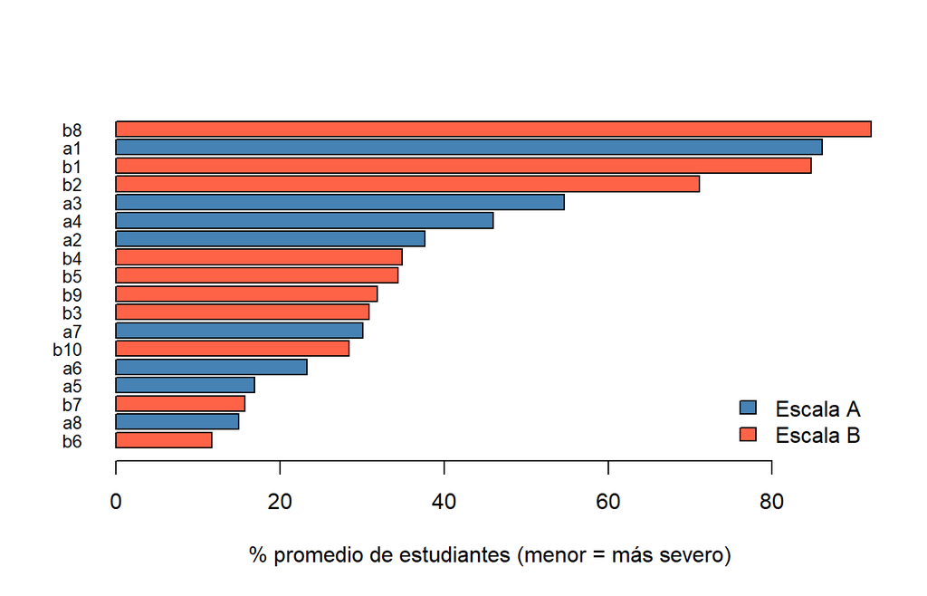

```r
medias <- sort(colMeans(d[c(items_A, items_B)]))
barplot(100 * medias, horiz = TRUE, las = 1, cex.names = .8,
        col = ifelse(grepl("^a", names(medias)), "steelblue", "tomato"),
        xlab = "% promedio de estudiantes (menor = más severo)")
legend("bottomright", c("Escala A", "Escala B"), fill = c("steelblue", "tomato"), bty = "n")
```

**Notas:**

- Guardamos los indicadores como proporciones (0–1) y no como porcentajes (0–100). Con varianzas muy grandes (cientos), lavaan puede tener problemas numéricos; por ejemplo, algunos índices de modificación no se calculan.
- Las proporciones se tratan como continuas. Varios indicadores severos se acercan a 0 en escuelas pequeñas; si se amontonan en 0 o 1, conviene transformarlos a logit.

# 3. Modelos de medición (CFA)

**Estimador.** Los indicadores son continuos, pero varios no son normales: los muy frecuentes (cerca de 1) y los muy severos (cerca de 0) son asimétricos.

```r
asim <- function(x) mean((x - mean(x))^3) / sd(x)^3
round(sapply(d[c(items_A, items_B)], asim), 2)
```

```
##    a1    a2    a3    a4    a5    a6    a7    a8    b1    b2    b3    b4    b5
## -1.53  0.45 -0.24  0.07  1.74  1.08  0.76  1.69 -1.73 -0.80  0.70  0.55  0.66
##    b6    b7    b8    b9   b10
##  2.16  1.63 -2.60  0.75  0.85
```

Por eso usamos **MLR** (máxima verosimilitud robusta). Las estimaciones puntuales (cargas, varianzas) son las mismas que con ML; lo que cambia es que los errores estándar y el chi-cuadrado se corrigen por la falta de normalidad. En consecuencia reportamos el chi-cuadrado escalado y los índices `.robust`.

**Identificación.** Con `std.lv = TRUE` la varianza del factor es 1, así los puntajes quedan en desviaciones estándar entre escuelas.

Estimamos cada escala de dos formas: primero el modelo básico, sin correlaciones entre errores; luego un modelo que permite que los errores de algunos indicadores estén correlacionados.

## 3.1 Modelo sin correlaciones entre errores

El CFA básico supone **independencia local**: una vez que conocemos la intensidad de uso de IA de una escuela (el factor), los indicadores ya no tienen nada más en común. Todo lo que comparten se debe al factor, y sus errores no están correlacionados.

```r
mod_A_sin <- 'IA =~ a1 + a2 + a3 + a4 + a5 + a6 + a7 + a8'
mod_B_sin <- 'IA =~ b1 + b2 + b3 + b4 + b5 + b6 + b7 + b8 + b9 + b10'

fit_A_sin <- cfa(mod_A_sin, data = d, std.lv = TRUE, estimator = "MLR")
fit_B_sin <- cfa(mod_B_sin, data = d, std.lv = TRUE, estimator = "MLR")
```

### La salida completa de lavaan

`summary()` muestra todo lo que estimó lavaan. Con `fit.measures = TRUE` agrega los índices de ajuste, y con `standardized = TRUE` las estimaciones estandarizadas. Cómo leerla, de arriba abajo:

- **Encabezado:** estimador (ML con corrección robusta), número de parámetros libres y de observaciones (400 escuelas).
- **Model Test User Model:** chi-cuadrado del modelo. La columna `Standard` es el chi-cuadrado de ML; la columna `Scaled` es la versión robusta, que es la que se reporta. Un p-valor bajo indica que el modelo no reproduce exactamente las covarianzas.
- **Model Test Baseline Model:** chi-cuadrado de un modelo “nulo” en que los indicadores no se correlacionan. Sirve de referencia para CFI y TLI.
- **User Model versus Baseline Model:** CFI y TLI (usar las filas *Robust*).
- **Loglikelihood and Information Criteria:** AIC y BIC, útiles para comparar modelos (menor es mejor).
- **Root Mean Square Error of Approximation:** RMSEA con su intervalo de confianza (usar las filas *Robust*).
- **Standardized Root Mean Square Residual:** SRMR, el promedio de las diferencias entre correlaciones observadas y predichas por el modelo.
- **Parameter Estimates:** tipo de error estándar. `Sandwich` indica errores estándar robustos (MLR).
- **Latent Variables:** las cargas. `Estimate` es la carga no estandarizada (en proporción del indicador por DE del factor), `Std.Err` su error estándar robusto, `z` y `P(>|z|)` la prueba de que es distinta de 0. `Std.lv` estandariza solo el factor; `Std.all` estandariza factor e indicador, y es la carga que interpretamos.
- **Intercepts:** si aparecen, son las medias de los indicadores (el porcentaje promedio de cada conducta).
- **Variances:** varianzas residuales (error) de cada indicador y varianza del factor (fijada en 1). En `Std.all`, la varianza residual es 1 − carga².

```r
summary(fit_A_sin, fit.measures = TRUE, standardized = TRUE)
```

```
## lavaan 0.6-19 ended normally after 73 iterations
##
##   Estimator                                         ML
##   Optimization method                           NLMINB
##   Number of model parameters                        16
##
##   Number of observations                           400
##
## Model Test User Model:
##                                               Standard      Scaled
##   Test Statistic                                45.226      45.438
##   Degrees of freedom                                20          20
##   P-value (Chi-square)                           0.001       0.001
##   Scaling correction factor                                  0.995
##     Yuan-Bentler correction (Mplus variant)
##
## Model Test Baseline Model:
##
##   Test statistic                               723.147     708.321
##   Degrees of freedom                                28          28
##   P-value                                        0.000       0.000
##   Scaling correction factor                                  1.021
##
## User Model versus Baseline Model:
##
##   Comparative Fit Index (CFI)                    0.964       0.963
##   Tucker-Lewis Index (TLI)                       0.949       0.948
##
##   Robust Comparative Fit Index (CFI)                         0.964
##   Robust Tucker-Lewis Index (TLI)                            0.949
##
## Loglikelihood and Information Criteria:
##
##   Loglikelihood user model (H0)               1260.545    1260.545
##   Scaling correction factor                                  1.282
##       for the MLR correction
##   Loglikelihood unrestricted model (H1)       1283.158    1283.158
##   Scaling correction factor                                  1.123
##       for the MLR correction
##
```

[output cut: 36 more lines]

```
##     a6                0.098    0.010    9.951    0.000    0.098    0.533
##     a7                0.107    0.011   10.190    0.000    0.107    0.528
##     a8                0.081    0.009    9.411    0.000    0.081    0.565
##
## Variances:
##                    Estimate  Std.Err  z-value  P(>|z|)   Std.lv  Std.all
##    .a1                0.012    0.001    9.264    0.000    0.012    0.711
##    .a2                0.029    0.002   12.763    0.000    0.029    0.617
##    .a3                0.034    0.002   14.846    0.000    0.034    0.674
##    .a4                0.029    0.003   11.177    0.000    0.029    0.572
##    .a5                0.014    0.002    9.053    0.000    0.014    0.596
##    .a6                0.024    0.002   10.631    0.000    0.024    0.716
##    .a7                0.030    0.002   12.543    0.000    0.030    0.721
##    .a8                0.014    0.002    8.008    0.000    0.014    0.680
##     IA                1.000                               1.000    1.000
```

Normalmente no se reporta toda la salida: se extraen los índices que interesan con `fitMeasures()`.

```r
indices <- c("chisq.scaled", "df", "pvalue.scaled",
             "cfi.robust", "tli.robust", "rmsea.robust", "srmr")
round(rbind(A_sin = fitMeasures(fit_A_sin, indices),
            B_sin = fitMeasures(fit_B_sin, indices)), 3)
```

```
##       chisq.scaled df pvalue.scaled cfi.robust tli.robust rmsea.robust  srmr
## A_sin       45.438 20         0.001      0.964      0.949        0.056 0.037
## B_sin      123.881 35         0.000      0.704      0.619        0.079 0.067
```

La escala A ajusta de forma aceptable (TLI cerca de .95), pero no del todo bien. La escala B ajusta mal. Los índices de modificación de A indican dónde está la tensión:

```r
head(modindices(fit_A_sin, sort. = TRUE), 5)[, c("lhs", "op", "rhs", "mi")]
```

```
##    lhs op rhs     mi
## 45  a7 ~~  a8 18.601
## 39  a4 ~~  a8 12.356
## 36  a4 ~~  a5  9.239
## 29  a2 ~~  a7  8.189
## 21  a1 ~~  a5  2.599
```

Entre los índices más altos aparecen pares de indicadores de la **misma conducta** con distinta frecuencia: a7–a8 (párrafos, una vez / a veces) y a4–a5 (resolver, una vez / siempre). También aparecen pares sin relación de contenido (a4–a8, a2–a7). Los pares de la misma conducta tienen sentido: una escuela donde muchos estudiantes entregan párrafos de IA “al menos una vez” también tendrá más estudiantes que lo hacen “a veces”, por razones que van más allá del uso de IA en general (por ejemplo, cuánto se escribe en sus cursos o qué tan fácil es detectarlo). Esa propensión específica a la conducta es varianza compartida que el factor no explica.

## 3.2 Modelo con correlaciones entre errores

Agregamos **covarianzas residuales** (`~~`) entre los indicadores de una misma conducta. La decisión se toma **a priori, por el diseño del cuestionario**, no mirando los índices de modificación. Por eso liberamos todos los pares de diseño (a1–a2, a4–a5, a7–a8), y no otros pares con índices altos que no tienen justificación, como a4–a8 o a2–a7. Liberar pares solo porque el índice es alto lleva a modelos que se ajustan a las particularidades de la muestra.

```r
mod_A <- '
  IA =~ a1 + a2 + a3 + a4 + a5 + a6 + a7 + a8
  a1 ~~ a2        # explicar: una vez / siempre
  a4 ~~ a5        # resolver: una vez / siempre
  a7 ~~ a8        # párrafos: una vez / a veces
'
mod_B <- '
  IA =~ b1 + b2 + b3 + b4 + b5 + b6 + b7 + b8 + b9 + b10
  b2 ~~ b3        # comprobar: una vez / siempre
  b5 ~~ b6        # código: una vez / siempre
'
fit_A <- cfa(mod_A, data = d, std.lv = TRUE, estimator = "MLR")
fit_B <- cfa(mod_B, data = d, std.lv = TRUE, estimator = "MLR")

round(rbind(A_sin = fitMeasures(fit_A_sin, indices),
            A_con = fitMeasures(fit_A, indices),
            B_sin = fitMeasures(fit_B_sin, indices),
            B_con = fitMeasures(fit_B, indices)), 3)
```

```
##       chisq.scaled df pvalue.scaled cfi.robust tli.robust rmsea.robust  srmr
## A_sin       45.438 20         0.001      0.964      0.949        0.056 0.037
## A_con       18.975 17         0.330      0.997      0.995        0.017 0.024
## B_sin      123.881 35         0.000      0.704      0.619        0.079 0.067
## B_con      104.123 33         0.000      0.765      0.680        0.073 0.062
```

Como el modelo sin correlaciones es un caso particular del modelo con correlaciones (covarianzas fijadas en 0), podemos compararlos con una prueba de diferencia de chi-cuadrado. Con MLR, `anova()` aplica automáticamente la corrección de Satorra-Bentler (la columna `Chisq` muestra el chi-cuadrado sin corregir, pero la prueba de diferencia sí está corregida):

```r
anova(fit_A, fit_A_sin)
```

```
##
## Scaled Chi-Squared Difference Test (method = "satorra.bentler.2001")
##
## lavaan->lavTestLRT():
##    lavaan NOTE: The "Chisq" column contains standard test statistics, not the
##    robust test that should be reported per model. A robust difference test is
##    a function of two standard (not robust) statistics.
##           Df     AIC     BIC  Chisq Chisq diff Df diff Pr(>Chisq)
## fit_A     17 -2509.2 -2433.4 19.118
## fit_A_sin 20 -2489.1 -2425.2 45.226     28.181       3  3.327e-06 ***
## ---
## Signif. codes:  0 '***' 0.001 '**' 0.01 '*' 0.05 '.' 0.1 ' ' 1
```

Las correlaciones residuales estimadas (estandarizadas):

```r
cr_A <- subset(standardizedSolution(fit_A), op == "~~" & lhs != rhs)
cr_B <- subset(standardizedSolution(fit_B), op == "~~" & lhs != rhs)
rbind(cr_A, cr_B)[, c("lhs", "rhs", "est.std", "pvalue")]
```

```
##     lhs rhs est.std pvalue
## 9    a1  a2   0.049  0.378
## 10   a4  a5   0.164  0.006
## 11   a7  a8   0.223  0.000
## 111  b2  b3   0.150  0.011
## 12   b5  b6   0.243  0.000
```

**Lectura:**

- En A, agregar las tres correlaciones lleva el ajuste de aceptable a muy bueno, y la prueba de chi-cuadrado lo confirma. Además, los índices de a4–a8 y a2–a7 bajan: parte de esa tensión venía de los pares de diseño.
- La correlación a1–a2 es pequeña y no significativa. Igual se mantiene: la decisión fue a priori, y un parámetro cercano a 0 no daña el modelo.
- En B el ajuste mejora algo, pero sigue siendo malo: el problema principal de B no está en los pares de diseño sino en b8–b10.
- Ojo: en B el RMSEA puede parecer aceptable mientras CFI/TLI son muy bajos. Cuando los indicadores tienen mucho error, sus correlaciones son bajas y el RMSEA puede verse “bien” aunque el modelo sea malo. Por eso conviene mirar varios índices a la vez.

## 3.3 ¿Qué cambia al ignorar las correlaciones entre errores?

```r
data.frame(
  item      = paste0("a", 1:8),
  carga_sin = round(subset(standardizedSolution(fit_A_sin), op == "=~")$est.std, 2),
  carga_con = round(subset(standardizedSolution(fit_A),     op == "=~")$est.std, 2))
```

```
##   item carga_sin carga_con
## 1   a1      0.54      0.54
## 2   a2      0.62      0.63
## 3   a3      0.57      0.58
## 4   a4      0.65      0.63
## 5   a5      0.64      0.61
## 6   a6      0.53      0.54
## 7   a7      0.53      0.49
## 8   a8      0.57      0.54
```

```r
round(c(omega_A_sin = compRelSEM(fit_A_sin), omega_A_con = compRelSEM(fit_A)), 3)
```

```
## omega_A_sin.IA omega_A_con.IA
##          0.801          0.778
```

- Sin las correlaciones, el factor absorbe parte de la varianza propia de cada conducta. Las cargas de los indicadores en pares (a4, a5, a7, a8) quedan algo **infladas**.
- Por lo mismo, omega queda **inflado**: el modelo sin correlaciones cuenta como “intensidad de uso” algo que en realidad es propensión a una conducta específica. El modelo con correlaciones trata esa varianza compartida como error y da una confiabilidad más honesta.
- En el resto del documento usamos los modelos con correlaciones (`fit_A`, `fit_B`).

## 3.4 Hipótesis de equivalencia tau (escala A)

El modelo que estimamos es **congenérico**: cada indicador tiene su propia carga. Un modelo más restrictivo es el **tau-equivalente**: todos los indicadores tienen la **misma carga no estandarizada**, es decir, todos miden el constructo con la misma intensidad. Este supuesto importa porque es el que hace que alfa de Cronbach sea igual a omega.

En lavaan, se impone con una etiqueta común (`l*`) para todas las cargas:

```r
mod_A_tau <- '
  IA =~ l*a1 + l*a2 + l*a3 + l*a4 + l*a5 + l*a6 + l*a7 + l*a8
  a1 ~~ a2
  a4 ~~ a5
  a7 ~~ a8
'
fit_A_tau <- cfa(mod_A_tau, data = d, std.lv = TRUE, estimator = "MLR")

round(rbind(congenerico     = fitMeasures(fit_A, indices),
            tau_equivalente = fitMeasures(fit_A_tau, indices)), 3)
```

```
##                 chisq.scaled df pvalue.scaled cfi.robust tli.robust
## congenerico           18.975 17          0.33      0.997      0.995
## tau_equivalente       84.759 24          0.00      0.908      0.893
##                 rmsea.robust  srmr
## congenerico            0.017 0.024
## tau_equivalente        0.081 0.106
```

```r
anova(fit_A, fit_A_tau)
```

```
##
## Scaled Chi-Squared Difference Test (method = "satorra.bentler.2001")
##
## lavaan->lavTestLRT():
##    lavaan NOTE: The "Chisq" column contains standard test statistics, not the
##    robust test that should be reported per model. A robust difference test is
##    a function of two standard (not robust) statistics.
##           Df     AIC     BIC  Chisq Chisq diff Df diff Pr(>Chisq)
## fit_A     17 -2509.2 -2433.4 19.118
## fit_A_tau 24 -2453.4 -2405.5 88.949     60.658       7  1.116e-10 ***
## ---
## Signif. codes:  0 '***' 0.001 '**' 0.01 '*' 0.05 '.' 0.1 ' ' 1
```

Las cargas no estandarizadas del modelo congenérico muestran por qué se rechaza:

```r
subset(parameterEstimates(fit_A), op == "=~")[, c("rhs", "est", "se")]
```

```
##   rhs   est    se
## 1  a1 0.070 0.007
## 2  a2 0.136 0.011
## 3  a3 0.131 0.011
## 4  a4 0.143 0.011
## 5  a5 0.094 0.010
## 6  a6 0.099 0.010
## 7  a7 0.101 0.010
## 8  a8 0.078 0.008
```

**Lectura:**

- El modelo tau-equivalente ajusta mucho peor y la prueba de chi-cuadrado lo rechaza con claridad.
- Las cargas no estandarizadas van de 0.07 a 0.14: los indicadores muy frecuentes (a1) o muy severos (a5, a8) varían poco entre escuelas y tienen cargas menores en la métrica de proporciones.
- Si la equivalencia tau no se cumple, alfa no es igual a omega. Además, alfa ignora las correlaciones entre errores. Ver el Anexo.

```r
round(c(omega = compRelSEM(fit_A),
        alfa  = compRelSEM(fit_A, tau.eq = TRUE)), 3)
```

```
## omega.IA  alfa.IA
##    0.778    0.794
```

Aquí alfa es **mayor** que omega. Se suele decir que alfa es un “límite inferior” de la confiabilidad, pero eso solo vale si no hay correlaciones entre errores. Alfa cuenta la varianza compartida por las variantes de una misma conducta como si fuera constructo, así que la sobreestima.

## 3.5 Comparación de cargas entre A y B

```r
cA <- subset(standardizedSolution(fit_A), op == "=~")
cB <- subset(standardizedSolution(fit_B), op == "=~")

comp <- data.frame(
  conducta   = c("Explicar concepto", "Explicar concepto",
                 "Comprobar respuestas", "Comprobar respuestas", "Comprobar respuestas",
                 "Resolver ejercicio", "Resolver ejercicio", "Resolver ejercicio",
                 "Código sin entender", "Código sin entender", "Código sin entender",
                 "Párrafos sin modificar", "Párrafos sin modificar",
                 "Evaluación prohibida", "IA para cualquier cosa",
                 "Uso personal", "Entretenimiento"),
  frecuencia = c("una vez", "siempre", "una vez", "a veces", "siempre",
                 "una vez", "a veces", "siempre", "una vez", "a veces", "siempre",
                 "una vez", "a veces", "una vez", "una vez", "siempre", "siempre"),
  item_A = c("a1", "a2", NA, "a3", NA, "a4", NA, "a5", NA, "a6", NA, "a7", "a8", NA, NA, NA, NA),
  item_B = c("b1", NA, "b2", NA, "b3", NA, "b4", NA, "b5", NA, "b6", NA, NA, "b7", "b8", "b9", "b10"))
comp$carga_A <- round(cA$est.std[match(comp$item_A, cA$rhs)], 2)
comp$carga_B <- round(cB$est.std[match(comp$item_B, cB$rhs)], 2)
comp
```

```
##                  conducta frecuencia item_A item_B carga_A carga_B
## 1       Explicar concepto    una vez     a1     b1    0.54    0.39
## 2       Explicar concepto    siempre     a2   <NA>    0.63      NA
## 3    Comprobar respuestas    una vez   <NA>     b2      NA    0.36
## 4    Comprobar respuestas    a veces     a3   <NA>    0.58      NA
## 5    Comprobar respuestas    siempre   <NA>     b3      NA    0.42
## 6      Resolver ejercicio    una vez     a4   <NA>    0.63      NA
## 7      Resolver ejercicio    a veces   <NA>     b4      NA    0.42
## 8      Resolver ejercicio    siempre     a5   <NA>    0.61      NA
## 9     Código sin entender    una vez   <NA>     b5      NA    0.56
## 10    Código sin entender    a veces     a6   <NA>    0.54      NA
## 11    Código sin entender    siempre   <NA>     b6      NA    0.39
## 12 Párrafos sin modificar    una vez     a7   <NA>    0.49      NA
## 13 Párrafos sin modificar    a veces     a8   <NA>    0.54      NA
## 14   Evaluación prohibida    una vez   <NA>     b7      NA    0.22
## 15 IA para cualquier cosa    una vez   <NA>     b8      NA    0.05
## 16           Uso personal    siempre   <NA>     b9      NA    0.23
## 17        Entretenimiento    siempre   <NA>    b10      NA    0.26
```

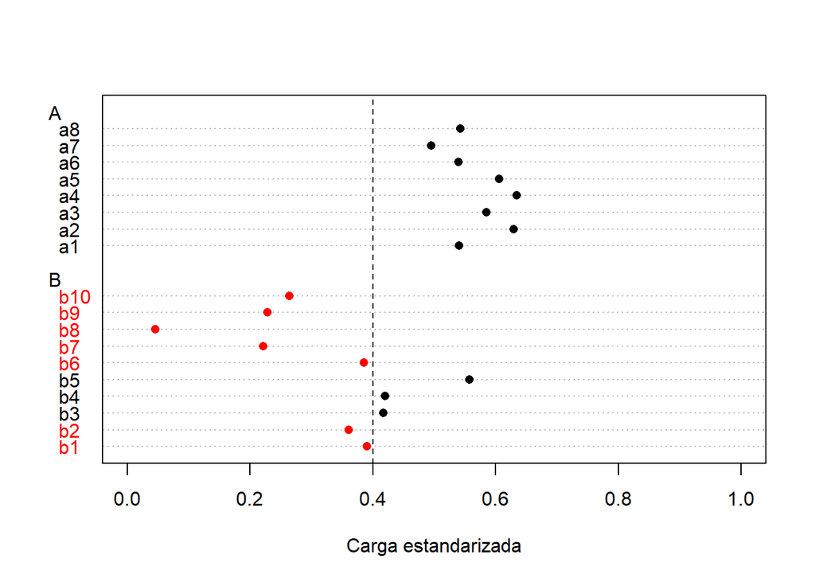

```r
cargas <- rbind(data.frame(escala = "A", item = cA$rhs, carga = cA$est.std),
                data.frame(escala = "B", item = cB$rhs, carga = cB$est.std))

dotchart(cargas$carga, labels = cargas$item, groups = factor(cargas$escala),
         pch = 16, col = ifelse(cargas$carga < .40, "red", "black"),
         xlim = c(0, 1), xlab = "Carga estandarizada")
abline(v = .40, lty = 2)
```

**Lectura:**

- Las conductas académicas cargan en todos los niveles de frecuencia: tanto usos leves como severos reflejan el mismo constructo.
- Las cargas de B son más bajas que las de A para contenidos equivalentes: sus preguntas tienen más error. Varias cargas académicas de B (b1, b2, b6, b7) quedan cerca o bajo .40 aunque su contenido es correcto; el problema es la redacción, no el constructo.
- b8 no carga: casi todos los estudiantes han usado IA alguna vez, así que el porcentaje no distingue escuelas.
- b9 y b10 cargan poco: el uso no académico refleja afinidad tecnológica, no intensidad de uso académico.

```r
head(modindices(fit_B, sort. = TRUE), 3)[, c("lhs", "op", "rhs", "mi")]
```

```
##    lhs op rhs     mi
## 66  b9 ~~ b10 65.766
## 42  b3 ~~  b6  6.570
## 60  b6 ~~ b10  5.854
```

El índice de modificación de `b9 ~~ b10` es enorme: comparten un factor propio. A diferencia de los pares de diseño, aquí no hay razón a priori para liberar esa covarianza; la señal indica que esos indicadores sobran.

# 4. Confiabilidad: omega

```r
fit_B7 <- cfa('IA =~ b1 + b2 + b3 + b4 + b5 + b6 + b7
               b2 ~~ b3
               b5 ~~ b6', data = d, std.lv = TRUE, estimator = "MLR")          # B sin b8-b10

data.frame(
  escala = c("A", "B (10 indicadores)", "B depurada (7)"),
  omega  = c(compRelSEM(fit_A), compRelSEM(fit_B), compRelSEM(fit_B7))
)
```

```
##               escala     omega
## 1                  A 0.7782639
## 2 B (10 indicadores) 0.5598988
## 3     B depurada (7) 0.5616469
```

**Notas:**

- `compRelSEM()` incluye las covarianzas residuales en el denominador: la varianza compartida entre variantes de una misma conducta cuenta como error, no como constructo. Ignorarlas inflaría omega.
- Omega incluye el error muestral de cada escuela.
- Sacar b8–b10 casi no cambia omega: el problema principal de B es el error de sus indicadores académicos, que ningún recorte de ítems arregla. Hay que mejorar las preguntas.

# 5. El factor

## 5.1 Distribución y relación con la intensidad verdadera

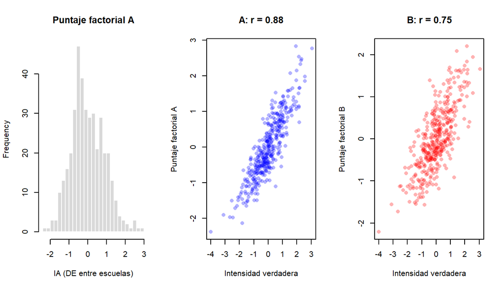

```r
d$fs_A <- as.numeric(lavPredict(fit_A))
d$fs_B <- as.numeric(lavPredict(fit_B))

par(mfrow = c(1, 3))
hist(d$fs_A, breaks = 25, col = "grey85", border = "white",
     main = "Puntaje factorial A", xlab = "IA (DE entre escuelas)")
plot(d$eta, d$fs_A, pch = 16, col = rgb(0, 0, 1, .3),
     main = paste("A: r =", round(cor(d$eta, d$fs_A), 2)),
     xlab = "Intensidad verdadera", ylab = "Puntaje factorial A")
plot(d$eta, d$fs_B, pch = 16, col = rgb(1, 0, 0, .3),
     main = paste("B: r =", round(cor(d$eta, d$fs_B), 2)),
     xlab = "Intensidad verdadera", ylab = "Puntaje factorial B")
```

```r
par(mfrow = c(1, 1))
```

Los puntajes factoriales de regresión tienen menos varianza que el factor verdadero (se “encogen” hacia la media), más cuanto menos confiable es la escala.

## 5.2 ¿Las dos escalas ordenan igual a las escuelas?

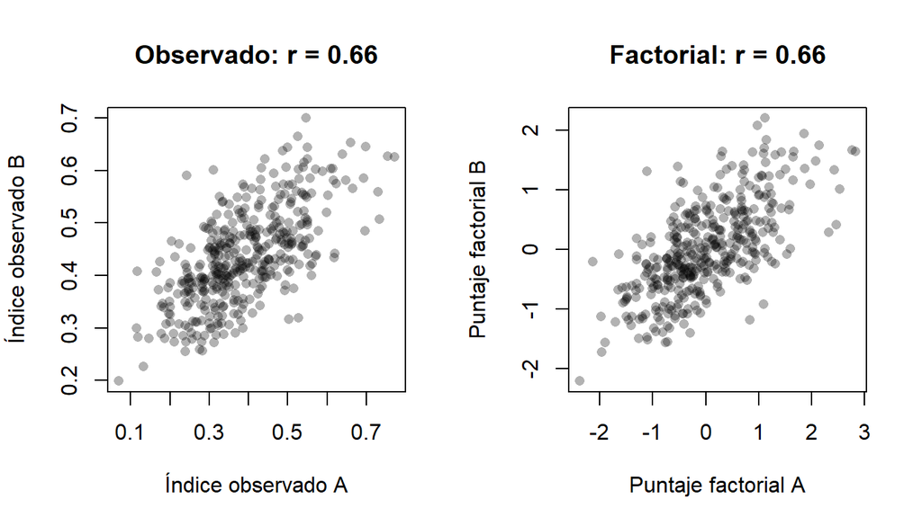

```r
d$ind_A <- rowMeans(d[items_A])            # índice observado: promedio simple
d$ind_B <- rowMeans(d[items_B])

par(mfrow = c(1, 2))
plot(d$ind_A, d$ind_B, pch = 16, col = rgb(0, 0, 0, .3),
     xlab = "Índice observado A", ylab = "Índice observado B",
     main = paste("Observado: r =", round(cor(d$ind_A, d$ind_B), 2)))
plot(d$fs_A, d$fs_B, pch = 16, col = rgb(0, 0, 0, .3),
     xlab = "Puntaje factorial A", ylab = "Puntaje factorial B",
     main = paste("Factorial: r =", round(cor(d$fs_A, d$fs_B), 2)))
```

```r
par(mfrow = c(1, 1))
```

Ambas escalas pretenden medir lo mismo, pero por el error de medición correlacionan bastante menos que 1. B, además, mezcla uso no académico: escuelas con estudiantes muy “tecnológicos” suben en B sin usar más IA en lo académico.

# 6. Comparaciones entre escuelas

## 6.1 Incertidumbre del puntaje de cada escuela

```r
fsA  <- lavPredict(fit_A, se = "standard")
se_A <- attr(fsA, "se")[[1]][1, 1]
se_A
```

```
##        IA
## 0.4644996
```

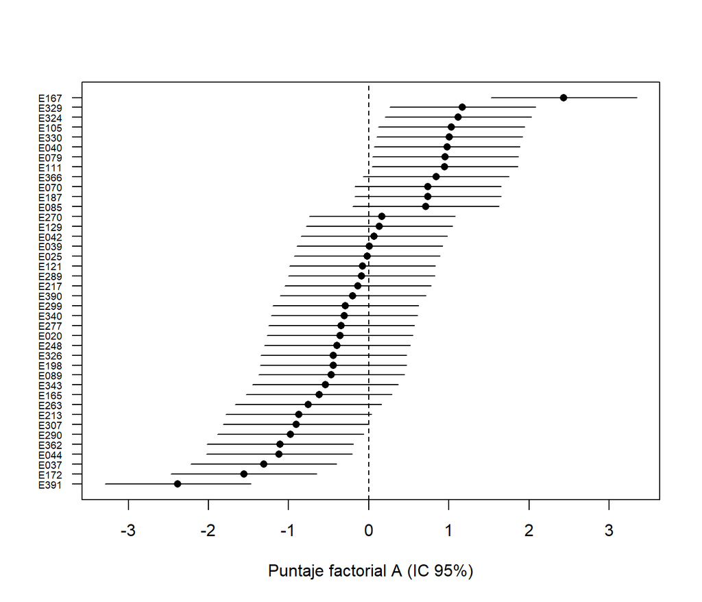

```r
set.seed(1)
m <- d[sample(J, 40), ]
m <- m[order(m$fs_A), ]

plot(m$fs_A, 1:40, pch = 16, xlim = range(m$fs_A) + c(-1, 1) * 2 * se_A,
     yaxt = "n", ylab = "", xlab = "Puntaje factorial A (IC 95%)")
segments(m$fs_A - 1.96 * se_A, 1:40, m$fs_A + 1.96 * se_A, 1:40)
axis(2, at = 1:40, labels = m$escuela, las = 1, cex.axis = .6)
abline(v = 0, lty = 2)
```

**Lectura:**

- Solo las escuelas de los extremos se distinguen claramente. En el medio, los intervalos se traslapan y un ranking fino no tiene respaldo.
- El CFA asigna el mismo error estándar a todas las escuelas. En realidad, las que encuestan a pocos estudiantes tienen más error muestral.

## 6.2 Observado vs factorial

El índice observado (promedio simple) da el mismo peso a todos los indicadores. El puntaje factorial pondera cada indicador según su carga y su error, así que b8–b10 casi no pesan.

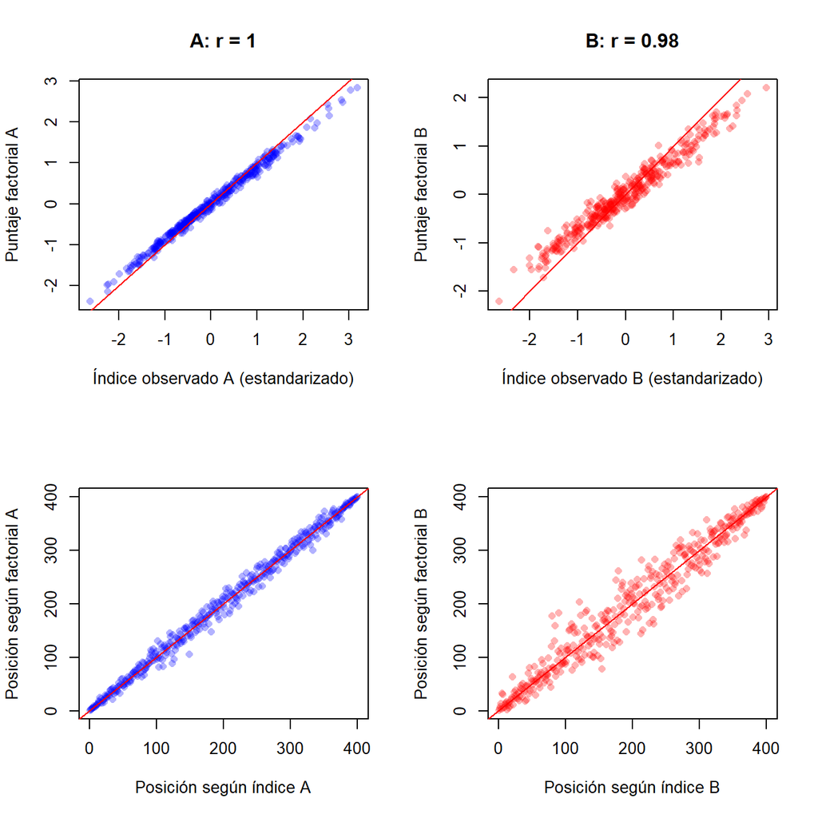

```r
par(mfrow = c(2, 2))
plot(scale(d$ind_A), d$fs_A, pch = 16, col = rgb(0, 0, 1, .3),
     xlab = "Índice observado A (estandarizado)", ylab = "Puntaje factorial A",
     main = paste("A: r =", round(cor(d$ind_A, d$fs_A), 2)))
abline(0, 1, col = "red")
plot(scale(d$ind_B), d$fs_B, pch = 16, col = rgb(1, 0, 0, .3),
     xlab = "Índice observado B (estandarizado)", ylab = "Puntaje factorial B",
     main = paste("B: r =", round(cor(d$ind_B, d$fs_B), 2)))
abline(0, 1, col = "red")
plot(rank(d$ind_A), rank(d$fs_A), pch = 16, col = rgb(0, 0, 1, .3),
     xlab = "Posición según índice A", ylab = "Posición según factorial A")
abline(0, 1, col = "red")
plot(rank(d$ind_B), rank(d$fs_B), pch = 16, col = rgb(1, 0, 0, .3),
     xlab = "Posición según índice B", ylab = "Posición según factorial B")
abline(0, 1, col = "red")
```

```r
par(mfrow = c(1, 1))
```

**Lectura:**

- Arriba: valores. Los puntajes factoriales tienen menos dispersión que el índice estandarizado (se encogen hacia la media).
- Abajo: posiciones en el ranking (1 = menor uso). Cuanto más se alejan los puntos de la diagonal, más cambia la posición de una escuela según el puntaje usado. En B la dispersión es mayor porque en el índice los indicadores malos pesan igual que los buenos.

## 6.3 ¿Cuál ordena mejor a las escuelas?

```r
# Correlación de rangos con la intensidad verdadera
round(cor(d[c("eta", "ind_A", "fs_A", "ind_B", "fs_B")], method = "spearman")[1, ], 3)
```

```
##   eta ind_A  fs_A ind_B  fs_B
## 1.000 0.869 0.869 0.716 0.725
```

```r
top30 <- function(x) rank(-x) <= 30
cat("Top 30 (B) compartido entre índice y puntaje factorial:",
    sum(top30(d$ind_B) & top30(d$fs_B)), "de 30\n")
```

```
## Top 30 (B) compartido entre índice y puntaje factorial: 27 de 30
```

```r
cat("Top 30 verdadero que recupera el índice B:",
    sum(top30(d$ind_B) & top30(d$eta)), "de 30\n")
```

```
## Top 30 verdadero que recupera el índice B: 18 de 30
```

```r
cat("Top 30 verdadero que recupera el puntaje factorial B:",
    sum(top30(d$fs_B) & top30(d$eta)), "de 30\n")
```

```
## Top 30 verdadero que recupera el puntaje factorial B: 17 de 30
```

```r
cat("Top 30 compartido entre puntaje factorial A y B:",
    sum(top30(d$fs_A) & top30(d$fs_B)), "de 30\n")
```

```
## Top 30 compartido entre puntaje factorial A y B: 13 de 30
```

# 7. El uso de IA como variable dependiente: atenuación

¿Cuánto explican el currículo y los recursos la intensidad de uso? Comparamos betas estandarizados.

**Nota:** el error aleatorio en la variable dependiente no sesga el coeficiente no estandarizado, pero sí atenúa el estandarizado y el R². Aproximadamente: beta observado ≈ beta verdadero × √confiabilidad.

```r
z   <- function(x) as.numeric(scale(x))
reg <- function(y) coef(lm(z(y) ~ z(cuant) + z(recursos), data = d))[-1]

tabla <- rbind(verdadero = reg(d$eta),
               indice_A  = reg(d$ind_A),
               fs_A      = reg(d$fs_A),
               indice_B  = reg(d$ind_B),
               fs_B      = reg(d$fs_B))
colnames(tabla) <- c("beta_cuant", "beta_recursos")
round(tabla, 3)
```

```
##           beta_cuant beta_recursos
## verdadero      0.387         0.347
## indice_A       0.314         0.267
## fs_A           0.309         0.271
## indice_B       0.235         0.241
## fs_B           0.250         0.250
```

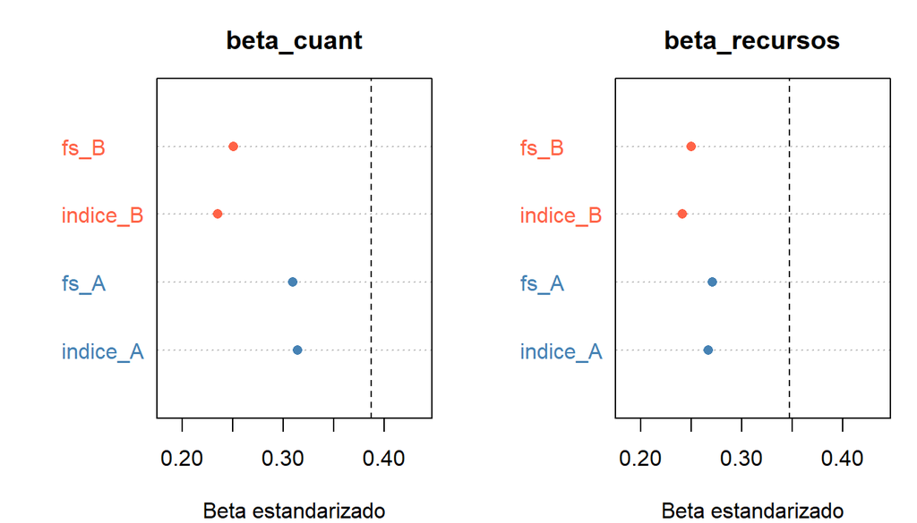

```r
par(mfrow = c(1, 2), mar = c(4, 6, 3, 1))
for (k in 1:2) {
  dotchart(tabla[-1, k], labels = rownames(tabla)[-1], pch = 16,
           col = rep(c("steelblue", "tomato"), each = 2),
           xlim = range(tabla) + c(-.05, .05),
           main = colnames(tabla)[k], xlab = "Beta estandarizado")
  abline(v = tabla["verdadero", k], col = "black", lty = 2)
}
```

```r
par(mfrow = c(1, 1))
```

La línea punteada es el beta verdadero. Los puntos a su izquierda muestran la atenuación.

**Lectura:**

- Con el índice observado los betas quedan por debajo de los verdaderos, bastante más en B, que tiene más error y menor omega.
- Los puntajes factoriales mejoran poco: también contienen error.
- Ninguno de los dos elimina la atenuación. Para corregirla hay que modelar el error de medición directamente (se verá más adelante).

# 8. Resumen

1. Variar la frecuencia (una vez / a veces / siempre) permite tener indicadores de distinta severidad para una misma conducta.
2. Esas variantes comparten varianza específica: se modela con covarianzas residuales a priori, justificadas por el diseño. Ignorarlas empeora el ajuste e infla cargas y omega.
3. Con indicadores asimétricos, MLR corrige errores estándar y chi-cuadrado; se reportan los índices robustos.
4. La equivalencia tau (cargas iguales) rara vez se cumple. Sin ella, y con errores correlacionados, alfa se aleja de omega (y puede sobreestimar).
5. Comparar cargas entre versiones de una escala muestra qué contenidos funcionan igual y cuáles fallan.
6. Indicadores con efecto techo o de otro constructo empeoran el ajuste, bajan omega y contaminan el índice.
7. Los puntajes de escuelas tienen incertidumbre: solo las diferencias grandes son interpretables.
8. Usar un índice con error como variable dependiente atenúa los efectos estandarizados, y los puntajes factoriales no lo corrigen.

# Anexo: alfa y beta con el paquete psych

El paquete `psych` calcula coeficientes de confiabilidad que no requieren estimar un CFA:

- **Alfa de Cronbach:** supone equivalencia tau y errores no correlacionados.
- **Beta de Revelle:** la peor división en mitades posible (*minimum split-half*). Es un límite inferior más conservador.
- **Lambda 4 de Guttman:** la mejor división en mitades (*maximum split-half*). Tiende a sobreestimar en muestras chicas.

```r
library(psych)

alfa_A <- psych::alpha(d[items_A])
alfa_A$total                                # raw_alpha: alfa sobre las proporciones originales
```

```
##  raw_alpha std.alpha   G6(smc) average_r      S/N        ase      mean       sd
##  0.7941665 0.8026471 0.7882214 0.3370385 4.067066 0.01513146 0.3871792 0.120774
##   median_r
##  0.3420545
```

```r
mitades_A <- splitHalf(d[items_A], covar = TRUE)
mitades_B <- splitHalf(d[items_B], covar = TRUE)
mitades_A
```

```
## Split half reliabilities
## Call: splitHalf(r = d[items_A], covar = TRUE)
##
## Maximum split half reliability (lambda 4) =  0.83
## Guttman lambda 6                          =  0.78
## Average split half reliability            =  0.79
## Guttman lambda 3 (alpha)                  =  0.79
## Guttman lambda 2                          =  0.8
## Minimum split half reliability  (beta)    =  0.75
## Average interitem covariance =  0.01  with median =  0.01
```

`covar = TRUE` hace que los cálculos usen covarianzas (la métrica original), igual que el índice simple y omega.

Comparación con omega:

```r
data.frame(
  escala   = c("A", "B"),
  omega    = c(compRelSEM(fit_A), compRelSEM(fit_B)),
  alfa     = c(mitades_A$alpha, mitades_B$alpha),
  beta     = c(mitades_A$minrb, mitades_B$minrb),
  lambda_4 = c(mitades_A$maxrb, mitades_B$maxrb)
)
```

```
##   escala     omega      alfa      beta  lambda_4
## 1      A 0.7782639 0.7941665 0.7478502 0.8310094
## 2      B 0.5598988 0.5822605 0.4225761 0.7023738
```

**Lectura:**

- **Alfa vs omega:** en A, alfa es algo mayor que omega porque trata como constructo la varianza compartida entre variantes de una misma conducta. En B ambos son bajos.
- **Beta:** siempre es menor o igual que alfa. En B cae mucho: existe una división en mitades que casi no se correlacionan entre sí, porque una de ellas concentra indicadores que no miden el constructo (b8–b10). Beta detecta así que la escala no es homogénea, algo que alfa oculta.
- **Lambda 4:** el máximo; muy optimista.
- **Conclusión:** alfa y los coeficientes de mitades no saben nada del modelo de medición. Omega, calculado desde un CFA que ajusta bien, usa lo que sabemos de la estructura de la escala (cargas distintas, errores correlacionados). Si el CFA ajusta mal (como en B), ningún coeficiente es confiable.